# Neural_Network_Bank_Churn_Prediction

## Bank Churn prediction

**Problem Statement**

Businesses like banks that provide service have to worry about the problem of 'Churn' i.e. customers leaving and joining another service provider. It is important to understand which aspects of the service influence a customer's decision in this regard. Management can concentrate efforts on the improvement of service, keeping in mind these priorities.

### **Objective**:

Build a neural network-based classifier that can determine whether bank customer will leave or not in the next 6 months.

### **Data Description**:

The dataset contains 10,000 sample points with 14 distinct features such as CustomerId, CreditScore, Geography, Gender, Age, Tenure, Balance, etc. The data contains the different attributes of a bank customer given below detailed data dictionary is given below.

- **CustomerId**: Unique ID which is assigned to each customer
- **Surname**: Last name of the customer
- **CreditScore**: It defines the credit history of the customer.
- **Geography**: A customer’s location
- **Gender**: It defines the Gender of the customer
- **Tenure**: Number of years for which the customer has been with the bank
- **NumOfProducts**: It refers to the number of products that a customer has purchased through the bank.
- **Balance**: Account balance
- **HasCrCard**: It is a categorical variable that decides whether the customer has a credit card or not.
- **EstimatedSalary**: Estimated salary
- **isActiveMember**: It is a categorical variable that decides whether the customer is an active member of the bank or not ( Active member in the sense, using bank products regularly, making transactions, etc )
- **Exited**: It is a categorical variable that decides whether the customer left the bank within six months or not. It can take two values

  ```
                0=No ( Customer did not leave the bank - Not Exited)

                1=Yes ( Customer left the bank - Exited)
  ```

### Importing Libraries

```python
import pandas as pd
import numpy as np
from sklearn.model_selection import train_test_split
from sklearn.preprocessing import LabelEncoder, OneHotEncoder
from sklearn import model_selection
from sklearn.compose import ColumnTransformer
import matplotlib.pyplot as plt
import seaborn as sns
from sklearn.impute import SimpleImputer
import warnings
from sklearn.metrics import confusion_matrix
from sklearn.pipeline import Pipeline
from sklearn.model_selection import GridSearchCV
from sklearn.model_selection import RandomizedSearchCV
import tensorflow as tf
from tensorflow.keras.models import Sequential
from tensorflow.keras.layers import Dense
from tensorflow.keras.layers import Dense, Input, Dropout,BatchNormalization
from tensorflow.keras.wrappers.scikit_learn import KerasClassifier
import random
from tensorflow.keras import backend
random.seed(1)
np.random.seed(1)
tf.random.set_seed(1)
warnings.filterwarnings("ignore")
```

### Loading Data

```python
from google.colab import files

uploaded = files.upload()
```

Upload widget is only available when the cell has been executed in the current browser session. Please rerun this cell to enable.

```
Saving Churn.csv to Churn (1).csv
```

```python
# Reading the data using Pandas Library
Data = pd.read_csv('/content/Churn.csv')
```

```python
# Examining the number of rows and columns in the data
Data.shape
```

```
(10000, 14)
```

There are 10000 observations and 14 attributes in the dataset

```python
# Examine the first 5 rows of the data
Data.head()
```

|  | RowNumber | CustomerId | Surname | CreditScore | Geography | Gender | Age | Tenure | Balance | NumOfProducts | HasCrCard | IsActiveMember | EstimatedSalary | Exited |
| --- | --- | --- | --- | --- | --- | --- | --- | --- | --- | --- | --- | --- | --- | --- |
| 0 | 1 | 15634602 | Hargrave | 619 | France | Female | 42 | 2 | 0.00 | 1 | 1 | 1 | 101348.88 | 1 |
| 1 | 2 | 15647311 | Hill | 608 | Spain | Female | 41 | 1 | 83807.86 | 1 | 0 | 1 | 112542.58 | 0 |
| 2 | 3 | 15619304 | Onio | 502 | France | Female | 42 | 8 | 159660.80 | 3 | 1 | 0 | 113931.57 | 1 |
| 3 | 4 | 15701354 | Boni | 699 | France | Female | 39 | 1 | 0.00 | 2 | 0 | 0 | 93826.63 | 0 |
| 4 | 5 | 15737888 | Mitchell | 850 | Spain | Female | 43 | 2 | 125510.82 | 1 | 1 | 1 | 79084.10 | 0 |

```python
# Examine the last 5 rows of the data
Data.tail()
```

|  | RowNumber | CustomerId | Surname | CreditScore | Geography | Gender | Age | Tenure | Balance | NumOfProducts | HasCrCard | IsActiveMember | EstimatedSalary | Exited |
| --- | --- | --- | --- | --- | --- | --- | --- | --- | --- | --- | --- | --- | --- | --- |
| 9995 | 9996 | 15606229 | Obijiaku | 771 | France | Male | 39 | 5 | 0.00 | 2 | 1 | 0 | 96270.64 | 0 |
| 9996 | 9997 | 15569892 | Johnstone | 516 | France | Male | 35 | 10 | 57369.61 | 1 | 1 | 1 | 101699.77 | 0 |
| 9997 | 9998 | 15584532 | Liu | 709 | France | Female | 36 | 7 | 0.00 | 1 | 0 | 1 | 42085.58 | 1 |
| 9998 | 9999 | 15682355 | Sabbatini | 772 | Germany | Male | 42 | 3 | 75075.31 | 2 | 1 | 0 | 92888.52 | 1 |
| 9999 | 10000 | 15628319 | Walker | 792 | France | Female | 28 | 4 | 130142.79 | 1 | 1 | 0 | 38190.78 | 0 |

```python
# Examine the datatypes of the columns in the dataset
Data.info()
```

```
<class 'pandas.core.frame.DataFrame'>
RangeIndex: 10000 entries, 0 to 9999
Data columns (total 14 columns):
 #   Column           Non-Null Count  Dtype
---  ------           --------------  -----
 0   RowNumber        10000 non-null  int64
 1   CustomerId       10000 non-null  int64
 2   Surname          10000 non-null  object
 3   CreditScore      10000 non-null  int64
 4   Geography        10000 non-null  object
 5   Gender           10000 non-null  object
 6   Age              10000 non-null  int64
 7   Tenure           10000 non-null  int64
 8   Balance          10000 non-null  float64
 9   NumOfProducts    10000 non-null  int64
 10  HasCrCard        10000 non-null  int64
 11  IsActiveMember   10000 non-null  int64
 12  EstimatedSalary  10000 non-null  float64
 13  Exited           10000 non-null  int64
dtypes: float64(2), int64(9), object(3)
memory usage: 1.1+ MB
```

- There are 10000 observations and 14 columns in the data.
- 3 columns are of the object datatype and 11 columns are numerical.

```python
# Examine the data for duplicate values
Data.duplicated().sum()
```

```
0
```

There are no duplicate values present in the data

```python
# We check for missing values in the data
round(Data.isnull().sum() / Data.isnull().count()* 100, 2)
```

```
RowNumber          0.0
CustomerId         0.0
Surname            0.0
CreditScore        0.0
Geography          0.0
Gender             0.0
Age                0.0
Tenure             0.0
Balance            0.0
NumOfProducts      0.0
HasCrCard          0.0
IsActiveMember     0.0
EstimatedSalary    0.0
Exited             0.0
dtype: float64
```

- There are no missing values in the data

```python
Data["Exited"].value_counts(1)
```

```
0    0.7963
1    0.2037
Name: Exited, dtype: float64
```

```python
# Check the statistical summary of the numerical columns in the data
Data.describe().T
```

|  | count | mean | std | min | 25% | 50% | 75% | max |
| --- | --- | --- | --- | --- | --- | --- | --- | --- |
| RowNumber | 10000.0 | 5.000500e+03 | 2886.895680 | 1.00 | 2500.75 | 5.000500e+03 | 7.500250e+03 | 10000.00 |
| CustomerId | 10000.0 | 1.569094e+07 | 71936.186123 | 15565701.00 | 15628528.25 | 1.569074e+07 | 1.575323e+07 | 15815690.00 |
| CreditScore | 10000.0 | 6.505288e+02 | 96.653299 | 350.00 | 584.00 | 6.520000e+02 | 7.180000e+02 | 850.00 |
| Age | 10000.0 | 3.892180e+01 | 10.487806 | 18.00 | 32.00 | 3.700000e+01 | 4.400000e+01 | 92.00 |
| Tenure | 10000.0 | 5.012800e+00 | 2.892174 | 0.00 | 3.00 | 5.000000e+00 | 7.000000e+00 | 10.00 |
| Balance | 10000.0 | 7.648589e+04 | 62397.405202 | 0.00 | 0.00 | 9.719854e+04 | 1.276442e+05 | 250898.09 |
| NumOfProducts | 10000.0 | 1.530200e+00 | 0.581654 | 1.00 | 1.00 | 1.000000e+00 | 2.000000e+00 | 4.00 |
| HasCrCard | 10000.0 | 7.055000e-01 | 0.455840 | 0.00 | 0.00 | 1.000000e+00 | 1.000000e+00 | 1.00 |
| IsActiveMember | 10000.0 | 5.151000e-01 | 0.499797 | 0.00 | 0.00 | 1.000000e+00 | 1.000000e+00 | 1.00 |
| EstimatedSalary | 10000.0 | 1.000902e+05 | 57510.492818 | 11.58 | 51002.11 | 1.001939e+05 | 1.493882e+05 | 199992.48 |
| Exited | 10000.0 | 2.037000e-01 | 0.402769 | 0.00 | 0.00 | 0.000000e+00 | 0.000000e+00 | 1.00 |

- The maximum age of customer is 92, the minimum age is 18 while the median age is 37.
- There are more active members/customer in the bank than non-active members. Over 50% of customers are active members.
- The highest customer tenure at the bank is 10years, while over 50% is over 5years at the bank.
- Credit score is very important in determining the credit worthiness of a customer. Hence the median score for customer is 652, while the miniumum is 350.
- Over 50% of customers in the bank has over 95000 dollars account balance.

```python
# Eaxmine the number of unique values in each column
unique_values = Data.nunique()

print("Unique values in each column:")
print(unique_values)
```

```
Unique values in each column:
RowNumber          10000
CustomerId         10000
Surname             2932
CreditScore          460
Geography              3
Gender                 2
Age                   70
Tenure                11
Balance             6382
NumOfProducts          4
HasCrCard              2
IsActiveMember         2
EstimatedSalary     9999
Exited                 2
dtype: int64
```

- Each value of the column 'RowNumber' and "CustomerId" is a unique identifier for a customer. Hence we can drop this column as it will not add any predictive power or value to the model.
- The 'Surname', "creditscore", "Balance" column has 2932, 460 and 6382 unique categories respectively.

```python
for i in Data.describe(include=["object"]).columns:
    print("Unique values in", i, "are :")
    print(Data[i].value_counts())
    print("*" * 50)
```

```
Unique values in Surname are :
Smith       32
Scott       29
Martin      29
Walker      28
Brown       26
            ..
Izmailov     1
Bold         1
Bonham       1
Poninski     1
Burbidge     1
Name: Surname, Length: 2932, dtype: int64
Unique values in Geography are :
France     5014
Germany    2509
Spain      2477
Name: Geography, dtype: int64
Unique values in Gender are :
Male      5457
Female    4543
Name: Gender, dtype: int64
```

### Data Pre-processing

```python
# RowNumber column consists of uniques ID for clients and hence will not add value to the modeling
Data.drop(columns="RowNumber", inplace=True)
```

```python
# CustomerId column consists of uniques ID for clients and hence will not add value to the modeling
Data.drop(columns="CustomerId", inplace=True)
```

```python
# Surname column consists of uniques ID for clients and hence will not add value to the modeling
Data.drop(columns="Surname", inplace=True)
```

```python
# Displaying the first 5 rows after removing uniques data that will not have values to the modeling.
Data.head()
```

|  | CreditScore | Geography | Gender | Age | Tenure | Balance | NumOfProducts | HasCrCard | IsActiveMember | EstimatedSalary | Exited |
| --- | --- | --- | --- | --- | --- | --- | --- | --- | --- | --- | --- |
| 0 | 619 | France | Female | 42 | 2 | 0.00 | 1 | 1 | 1 | 101348.88 | 1 |
| 1 | 608 | Spain | Female | 41 | 1 | 83807.86 | 1 | 0 | 1 | 112542.58 | 0 |
| 2 | 502 | France | Female | 42 | 8 | 159660.80 | 3 | 1 | 0 | 113931.57 | 1 |
| 3 | 699 | France | Female | 39 | 1 | 0.00 | 2 | 0 | 0 | 93826.63 | 0 |
| 4 | 850 | Spain | Female | 43 | 2 | 125510.82 | 1 | 1 | 1 | 79084.10 | 0 |

## **Performing Exploratory Data Analysis**

### Univariate Analysis

```python
# Function to plot a boxplot and a histogram along the same scale.


def histogram_boxplot(data, feature, figsize=(12, 7), kde=False, bins=None):
    """
    Boxplot and histogram combined

    data: dataframe
    feature: dataframe column
    figsize: size of figure (default (12,7))
    kde: whether to the show density curve (default False)
    bins: number of bins for histogram (default None)
    """
    f2, (ax_box2, ax_hist2) = plt.subplots(
        nrows=2,  # Number of rows of the subplot grid= 2
        sharex=True,  # x-axis will be shared among all subplots
        gridspec_kw={"height_ratios": (0.25, 0.75)},
        figsize=figsize,
    )  # creating the 2 subplots
    sns.boxplot(
        data=data, x=feature, ax=ax_box2, showmeans=True, color="violet"
    )  # boxplot will be created and a star will indicate the mean value of the column
    sns.histplot(
        data=data, x=feature, kde=kde, ax=ax_hist2, bins=bins, palette="winter"
    ) if bins else sns.histplot(
        data=data, x=feature, kde=kde, ax=ax_hist2
    )  # For histogram
    ax_hist2.axvline(
        data[feature].mean(), color="green", linestyle="--"
    )  # Add mean to the histogram
    ax_hist2.axvline(
        data[feature].median(), color="black", linestyle="-"
    )  # Add median to the histogram
```

```python
Data.dtypes
```

```
CreditScore          int64
Geography           object
Gender              object
Age                  int64
Tenure               int64
Balance            float64
NumOfProducts        int64
HasCrCard            int64
IsActiveMember       int64
EstimatedSalary    float64
Exited               int64
dtype: object
```

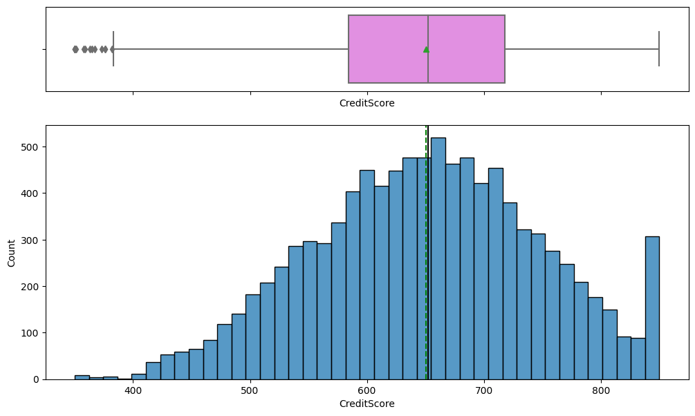

```python
histogram_boxplot(Data, "CreditScore")
```

- From the following plot, the average creditscore for the customers is about 650. Since the mean and median are very close the data is has normally distribution with little outlier. The outliers look genuine

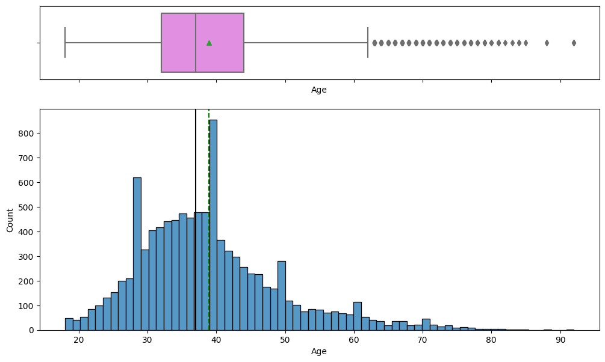

```python
histogram_boxplot(Data, "Age")
```

- The above plot is skewed to the right with some outliers which are real. The data is not normally distributed.
- There are lesser number of customers that are 65years and olders in the bank.
- majority of the customers are between 30 and 45 years old

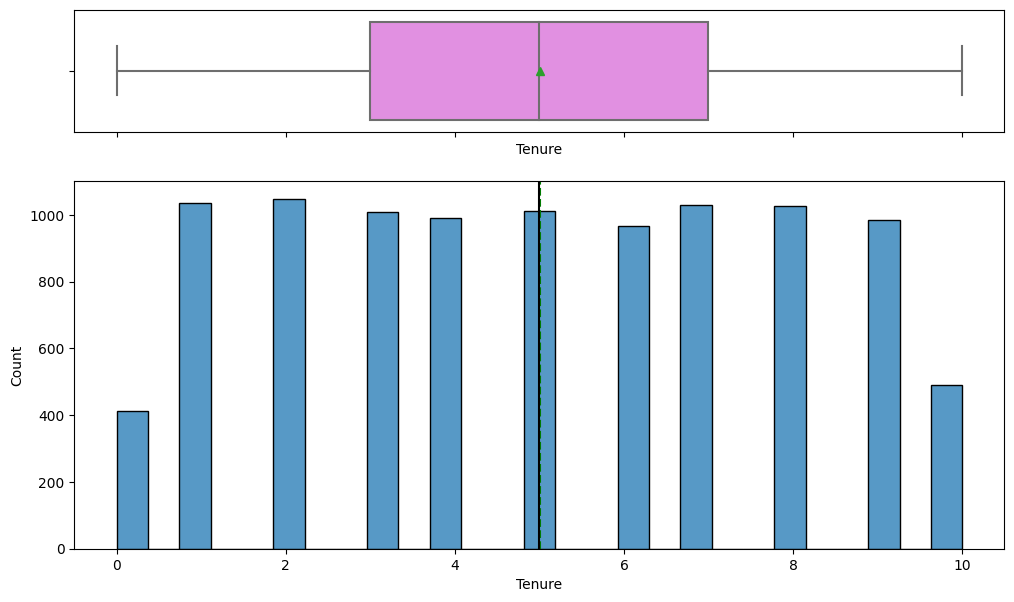

```python
histogram_boxplot(Data, "Tenure")
```

- From the following plot, the median tenure for the customers in the bank is 5years.

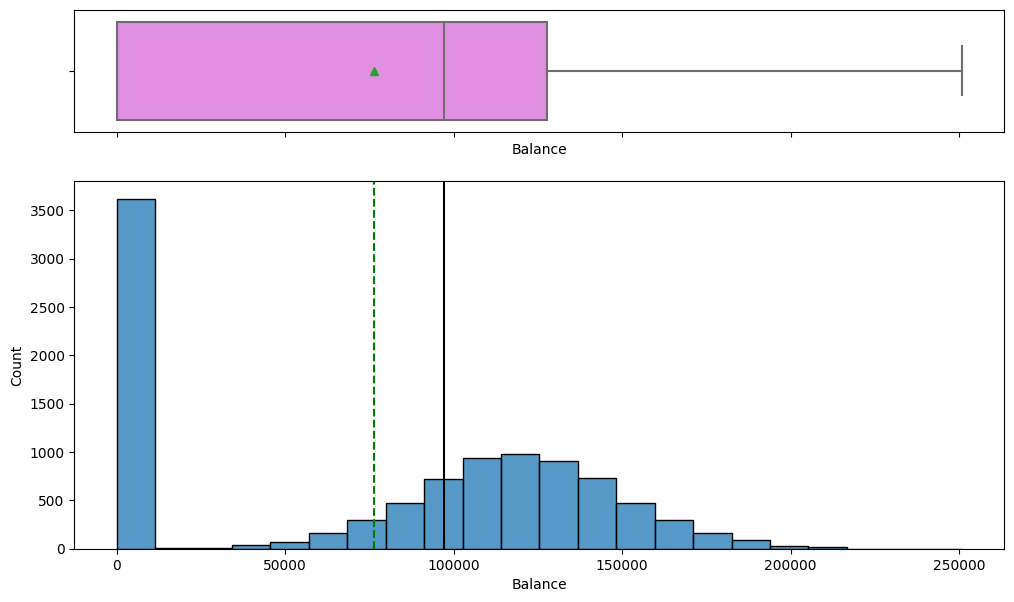

```python
histogram_boxplot(Data, "Balance")
```

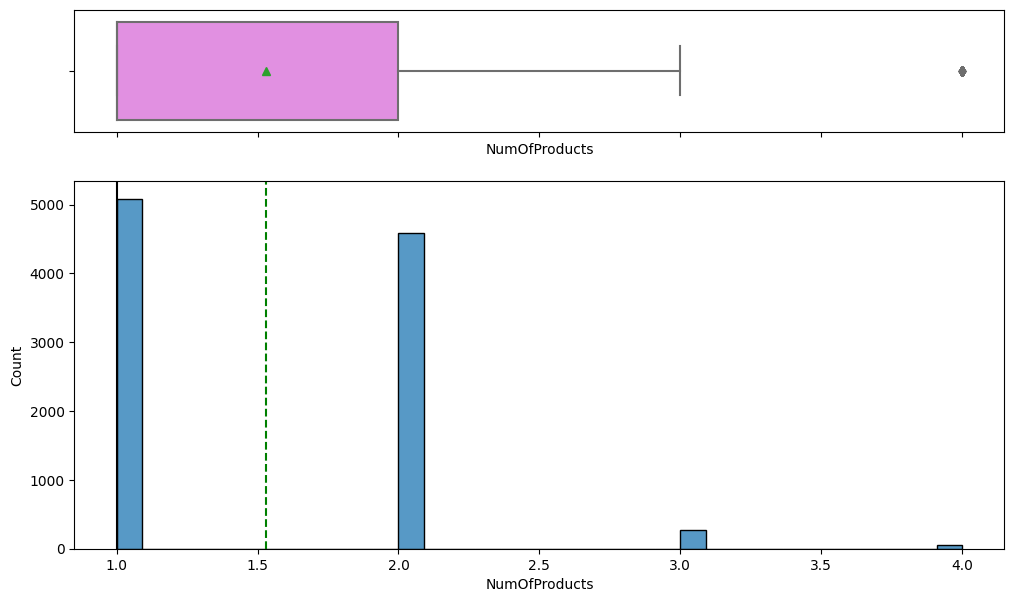

```python
histogram_boxplot(Data, "NumOfProducts")
```

- Majority of customers bought between 1 and 2 products from the bank

```python
# Function to create labeled barplots


def labeled_barplot(data, feature, perc=False, n=None):
    """
    Barplot with percentage at the top

    data: dataframe
    feature: dataframe column
    perc: whether to display percentages instead of count (default is False)
    n: displays the top n category levels (default is None, i.e., display all levels)
    """

    total = len(data[feature])  # length of the column
    count = data[feature].nunique()
    if n is None:
        plt.figure(figsize=(count + 1, 5))
    else:
        plt.figure(figsize=(n + 1, 5))

    plt.xticks(rotation=90, fontsize=15)
    ax = sns.countplot(
        data=data,
        x=feature,
        palette="Paired",
        order=data[feature].value_counts().index[:n].sort_values(),
    )

    for p in ax.patches:
        if perc == True:
            label = "{:.1f}%".format(
                100 * p.get_height() / total
            )  # percentage of each class of the category
        else:
            label = p.get_height()  # count of each level of the category

        x = p.get_x() + p.get_width() / 2  # width of the plot
        y = p.get_height()  # height of the plot

        ax.annotate(
            label,
            (x, y),
            ha="center",
            va="center",
            size=12,
            xytext=(0, 5),
            textcoords="offset points",
        )  # annotate the percentage

    plt.show()  # show the plot
```

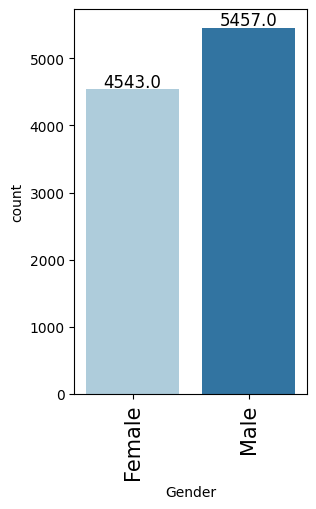

```python
labeled_barplot(Data, "Gender")
```

- There are relatively close number of gender in this dataset, hence it is balanced and not skewed.

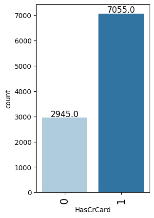

```python
labeled_barplot(Data, "HasCrCard")
```

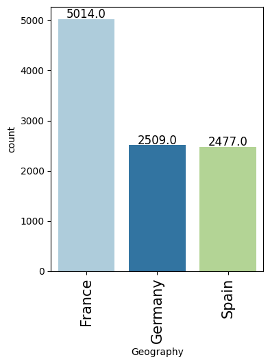

```python
labeled_barplot(Data, "Geography")
```

- France has more customers in the bank, while germany and spain has same number of customer.

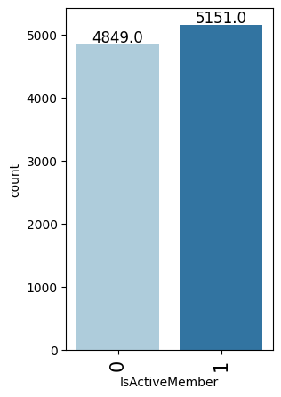

```python
labeled_barplot(Data, "IsActiveMember")
```

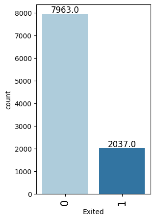

```python
labeled_barplot(Data, "Exited")
```

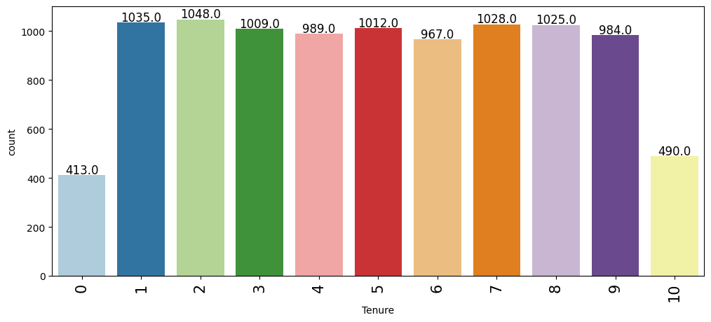

```python
labeled_barplot(Data, "Tenure")
```

```
0    7963
1    2037
Name: Exited, dtype: int64
```

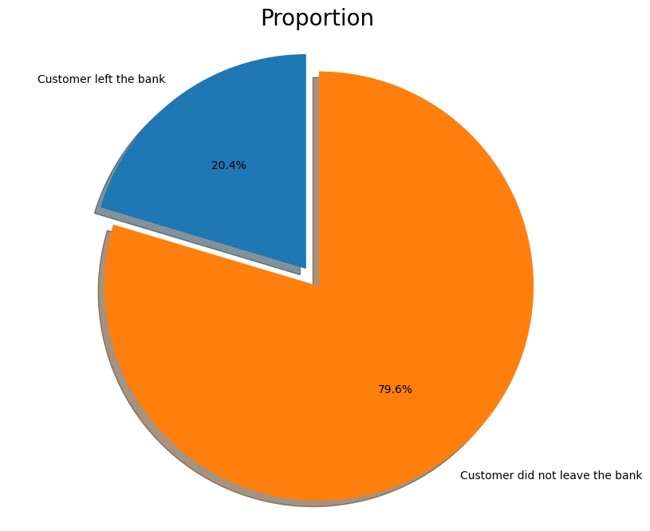

```python
print(Data.Exited.value_counts())
labels = 'Customer left the bank', 'Customer did not leave the bank'
sizes = [Data.Exited[Data['Exited']==1].count(),Data.Exited[Data['Exited']==0].count()]
explode = (0, 0.1)
fig1, ax1 = plt.subplots(figsize=(10, 8))
ax1.pie(sizes, explode=explode, labels=labels, autopct='%1.1f%%',
        shadow=True, startangle=90)
ax1.axis('equal')
plt.title("Proportion", size = 20)
plt.show()
```

Hence, this dataset and problem statement represent an example of Imbalanced Classification, which has unique challenges in comparison to performing classification over balanced target variables.

### Bivariate Analysis

```python
### Function to plot distributions


def distribution_plot_wrt_target(data, predictor, target):

    fig, axs = plt.subplots(2, 2, figsize=(12, 10))

    target_uniq = data[target].unique()

    axs[0, 0].set_title("Distribution of target for target=" + str(target_uniq[0]))
    sns.histplot(
        data=data[data[target] == target_uniq[0]],
        x=predictor,
        kde=True,
        ax=axs[0, 0],
        color="teal",
    )

    axs[0, 1].set_title("Distribution of target for target=" + str(target_uniq[1]))
    sns.histplot(
        data=data[data[target] == target_uniq[1]],
        x=predictor,
        kde=True,
        ax=axs[0, 1],
        color="orange",
    )

    axs[1, 0].set_title("Boxplot w.r.t target")
    sns.boxplot(data=data, x=target, y=predictor, ax=axs[1, 0], palette="gist_rainbow")

    axs[1, 1].set_title("Boxplot (without outliers) w.r.t target")
    sns.boxplot(
        data=data,
        x=target,
        y=predictor,
        ax=axs[1, 1],
        showfliers=False,
        palette="gist_rainbow",
    )

    plt.tight_layout()
    plt.show()
```

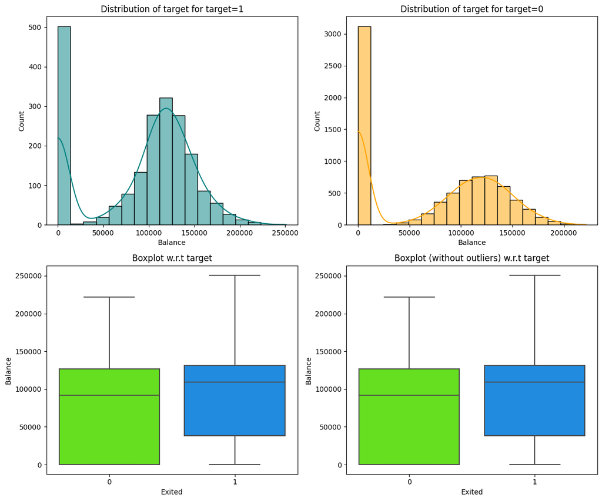

```python
distribution_plot_wrt_target(Data, "Balance", "Exited")
```

- From the above plot, we observe that customers with high balance from 100k and above are more likely to exit the bank.

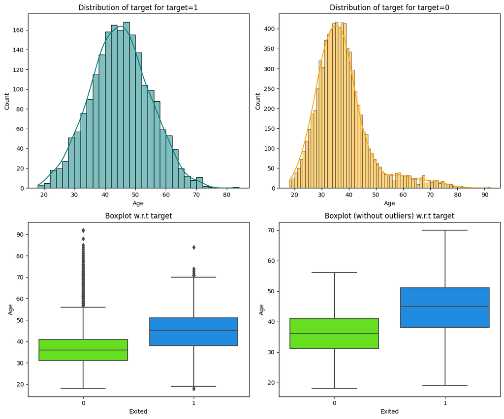

```python
distribution_plot_wrt_target(Data, "Age", "Exited")
```

```python
# function to plot stacked bar chart


def stacked_barplot(data, predictor, target):
    """
    Print the category counts and plot a stacked bar chart

    data: dataframe
    predictor: independent variable
    target: target variable
    """
    count = data[predictor].nunique()
    sorter = data[target].value_counts().index[-1]
    tab1 = pd.crosstab(data[predictor], data[target], margins=True).sort_values(
        by=sorter, ascending=False
    )
    print(tab1)
    print("-" * 120)
    tab = pd.crosstab(data[predictor], data[target], normalize="index").sort_values(
        by=sorter, ascending=False
    )
    tab.plot(kind="bar", stacked=True, figsize=(count + 1, 5))
    plt.legend(
        loc="lower left",
        frameon=False,
    )
    plt.legend(loc="upper left", bbox_to_anchor=(1, 1))
    plt.show()
```

```
Exited     0     1    All
Gender
All     7963  2037  10000
Female  3404  1139   4543
Male    4559   898   5457
------------------------------------------------------------------------------------------------------------------------
```

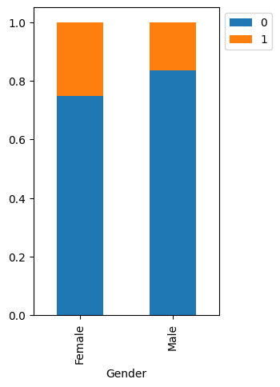

```python
stacked_barplot(Data, "Gender", "Exited")
```

```
Exited        0     1    All
Geography
All        7963  2037  10000
Germany    1695   814   2509
France     4204   810   5014
Spain      2064   413   2477
------------------------------------------------------------------------------------------------------------------------
```

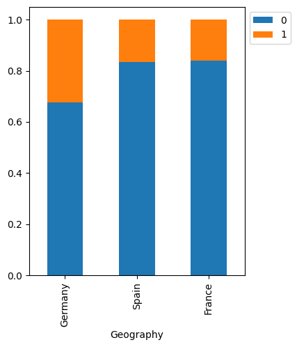

```python
stacked_barplot(Data, "Geography", "Exited")
```

- Germany has more percentage of customer likely to exit the bank compared to spain and france.

### Target variable Vs Numerical variables

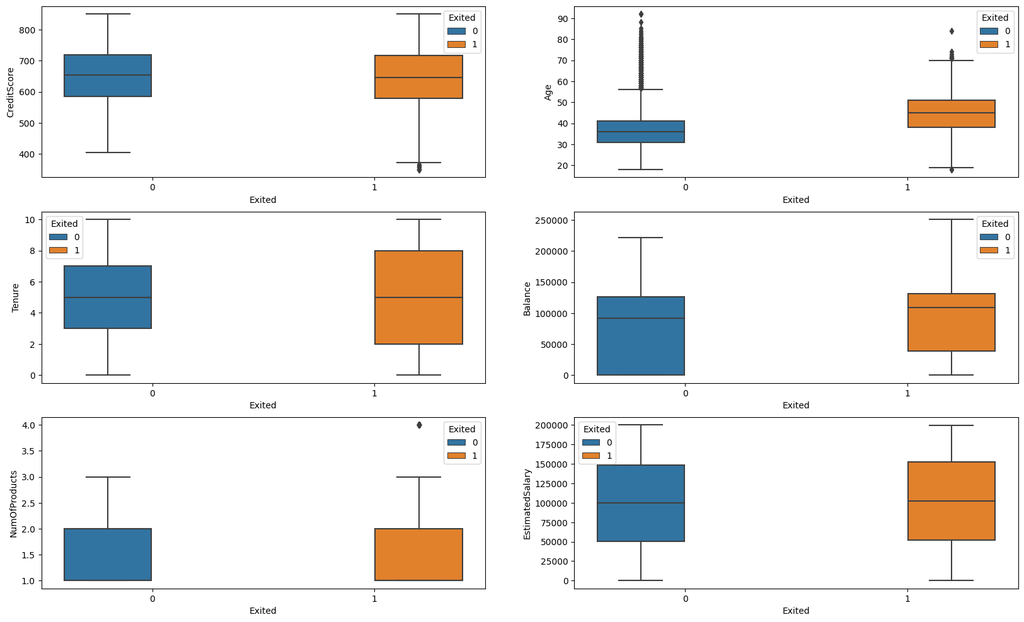

```python
fig, axarr = plt.subplots(3, 2, figsize=(20, 12))
sns.boxplot(y='CreditScore',x = 'Exited', hue = 'Exited',data = Data, ax=axarr[0][0])
sns.boxplot(y='Age',x = 'Exited', hue = 'Exited',data = Data , ax=axarr[0][1])
sns.boxplot(y='Tenure',x = 'Exited', hue = 'Exited',data = Data, ax=axarr[1][0])
sns.boxplot(y='Balance',x = 'Exited', hue = 'Exited',data = Data, ax=axarr[1][1])
sns.boxplot(y='NumOfProducts',x = 'Exited', hue = 'Exited',data = Data, ax=axarr[2][0])
sns.boxplot(y='EstimatedSalary',x = 'Exited', hue = 'Exited',data = Data, ax=axarr[2][1])
```

### Observation

- Apparent there are little to no difference in the credit score distribution between retained and churned customers. -The older customers are churning more than the younger ones due to a difference in service preference in the age categories. -The bank may need to review its target market or review the strategy for retention between the different age groups.
- Neither the product nor the salary has a significant effect on the likelihood to churn.

```
Exited     0     1    All
Tenure
All     7963  2037  10000
1        803   232   1035
3        796   213   1009
9        771   213    984
5        803   209   1012
4        786   203    989
2        847   201   1048
8        828   197   1025
6        771   196    967
7        851   177   1028
10       389   101    490
0        318    95    413
------------------------------------------------------------------------------------------------------------------------
```

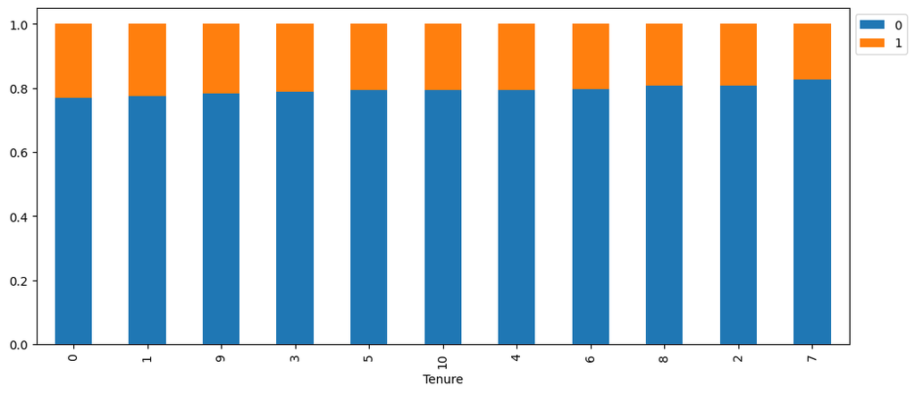

```python
stacked_barplot(Data, "Tenure", "Exited")
```

- Customers with about a year of less are likely to exit the bank compared to customers with more years on tenure. Although, the comparison is not significant.

```
Exited             0     1    All
IsActiveMember
All             7963  2037  10000
0               3547  1302   4849
1               4416   735   5151
------------------------------------------------------------------------------------------------------------------------
```

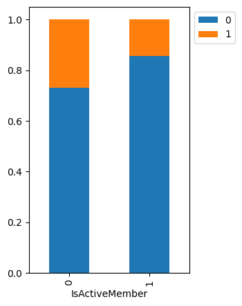

```python
stacked_barplot(Data, "IsActiveMember", "Exited")
```

- From the plot we can see that non-active members are likely to exit the bank than active members

```python
#Lets Drop the HasCrCard column since this might not add value to the modeling
Data.drop(['HasCrCard'], axis=1, inplace=True)
```

```python
## Separating Independent and Dependent Columns/variables
X = Data.drop(['Exited'],axis=1)
Y = Data[['Exited']]
```

```python
# Display first five rows after separating independent and dependent variables
X.head()
```

|  | CreditScore | Geography | Gender | Age | Tenure | Balance | NumOfProducts | IsActiveMember | EstimatedSalary |
| --- | --- | --- | --- | --- | --- | --- | --- | --- | --- |
| 0 | 619 | France | Female | 42 | 2 | 0.00 | 1 | 1 | 101348.88 |
| 1 | 608 | Spain | Female | 41 | 1 | 83807.86 | 1 | 1 | 112542.58 |
| 2 | 502 | France | Female | 42 | 8 | 159660.80 | 3 | 0 | 113931.57 |
| 3 | 699 | France | Female | 39 | 1 | 0.00 | 2 | 0 | 93826.63 |
| 4 | 850 | Spain | Female | 43 | 2 | 125510.82 | 1 | 1 | 79084.10 |

```python
Y.head()
```

|  | Exited |
| --- | --- |
| 0 | 1 |
| 1 | 0 |
| 2 | 1 |
| 3 | 0 |
| 4 | 0 |

```python
# Splitting the dataset into the Training and Testing set.

X_train, X_test, y_train, y_test = train_test_split(X,Y, test_size = 0.2, random_state = 42,stratify = Y, shuffle = True)
```

### Encoding Categorical Column

- We will be using the one-hot encoding technique to encode the values of the categorical column in this dataset.

```python
# Using one-hot encoding for the geography and Gender variable
X_train = pd.get_dummies(X_train, columns = ['Geography', 'Gender'], drop_first=True)
X_test = pd.get_dummies(X_test, columns = ['Geography', 'Gender'], drop_first=True)
```

```python
# Display first 5 rows of train split
X_train.head()
```

|  | CreditScore | Age | Tenure | Balance | NumOfProducts | IsActiveMember | EstimatedSalary | Geography_Germany | Geography_Spain | Gender_Male |
| --- | --- | --- | --- | --- | --- | --- | --- | --- | --- | --- |
| 2151 | 753 | 57 | 7 | 0.00 | 1 | 0 | 159475.08 | 0 | 0 | 1 |
| 8392 | 739 | 32 | 3 | 102128.27 | 1 | 0 | 63981.37 | 1 | 0 | 1 |
| 5006 | 755 | 37 | 0 | 113865.23 | 2 | 1 | 117396.25 | 1 | 0 | 0 |
| 4117 | 561 | 37 | 5 | 0.00 | 2 | 0 | 83093.25 | 0 | 0 | 1 |
| 7182 | 692 | 49 | 6 | 110540.43 | 2 | 1 | 107472.99 | 1 | 0 | 1 |

```python
# Display first 5 rows of test data
X_test.head()
```

|  | CreditScore | Age | Tenure | Balance | NumOfProducts | IsActiveMember | EstimatedSalary | Geography_Germany | Geography_Spain | Gender_Male |
| --- | --- | --- | --- | --- | --- | --- | --- | --- | --- | --- |
| 5702 | 585 | 36 | 7 | 0.00 | 2 | 0 | 94283.09 | 0 | 0 | 1 |
| 3667 | 525 | 33 | 4 | 131023.76 | 2 | 0 | 55072.93 | 1 | 0 | 1 |
| 1617 | 557 | 40 | 4 | 0.00 | 2 | 1 | 105433.53 | 0 | 1 | 0 |
| 5673 | 639 | 34 | 5 | 139393.19 | 2 | 0 | 33950.08 | 0 | 1 | 1 |
| 4272 | 640 | 34 | 3 | 77826.80 | 1 | 1 | 168544.85 | 0 | 1 | 0 |

```python
###Checking the shape of train and test sets after split
print(X_train.shape)
print(X_test.shape)
print(y_train.shape)
print(y_test.shape)
```

```
(8000, 10)
(2000, 10)
(8000, 1)
(2000, 1)
```

### Normalizing the train and test data separately using standardscaler

```python
# Importing library for Standard scaler
from sklearn.preprocessing import StandardScaler
```

```python
# Create an instance of StandardScaler
scaler = StandardScaler()

# Select the columns you want to standard scale
cols_to_scale = ['Balance', 'EstimatedSalary', 'CreditScore', 'Age', 'Tenure']

# Fit the scaler on the selected columns for training data
scaler.fit(X_train[cols_to_scale])

# Transform the selected columns using standard scaling for training data
X_train[cols_to_scale] = scaler.transform(X_train[cols_to_scale])
```

```python
# Fit the scaler on the selected columns for test data
scaler.fit(X_test[cols_to_scale])

# Transform the selected columns using standard scaling for test data
X_test[cols_to_scale] = scaler.transform(X_test[cols_to_scale])
```

```python
# Display first 5 rows after standard scaling/normalization
X_train.head()
```

|  | CreditScore | Age | Tenure | Balance | NumOfProducts | IsActiveMember | EstimatedSalary | Geography_Germany | Geography_Spain | Gender_Male |
| --- | --- | --- | --- | --- | --- | --- | --- | --- | --- | --- |
| 2151 | 1.058568 | 1.715086 | 0.684723 | -1.226059 | 1 | 0 | 1.042084 | 0 | 0 | 1 |
| 8392 | 0.913626 | -0.659935 | -0.696202 | 0.413288 | 1 | 0 | -0.623556 | 1 | 0 | 1 |
| 5006 | 1.079274 | -0.184931 | -1.731895 | 0.601687 | 2 | 1 | 0.308128 | 1 | 0 | 0 |
| 4117 | -0.929207 | -0.184931 | -0.005739 | -1.226059 | 2 | 0 | -0.290199 | 0 | 0 | 1 |
| 7182 | 0.427035 | 0.955079 | 0.339492 | 0.548318 | 2 | 1 | 0.135042 | 1 | 0 | 1 |

```python
X_train.shape
```

```
(8000, 10)
```

```python
# Display first 5 rows of test data after standard scaling
X_test.head()
```

|  | CreditScore | Age | Tenure | Balance | NumOfProducts | IsActiveMember | EstimatedSalary | Geography_Germany | Geography_Spain | Gender_Male |
| --- | --- | --- | --- | --- | --- | --- | --- | --- | --- | --- |
| 5702 | -0.667188 | -0.273247 | 0.696865 | -1.225072 | 2 | 0 | -0.124515 | 0 | 0 | 1 |
| 3667 | -1.286541 | -0.563678 | -0.347127 | 0.862105 | 2 | 0 | -0.798410 | 1 | 0 | 1 |
| 1617 | -0.956220 | 0.113994 | -0.347127 | -1.225072 | 2 | 1 | 0.067124 | 0 | 1 | 0 |
| 5673 | -0.109770 | -0.466868 | 0.000870 | 0.995428 | 2 | 0 | -1.161443 | 0 | 1 | 1 |
| 4272 | -0.099447 | -0.466868 | -0.695125 | 0.014690 | 1 | 1 | 1.151801 | 0 | 1 | 0 |

## **Model Building**

#### **A model could assume wrong predictions in the following ways:**

- Predicting a customer will exit a bank, when he/she is not exiting.
- Predicting a customer will not exit the bank, when he/she is in fact exiting.

#### **Which case is more important?**

Predicting that customer is not exiting but he/she is exiting. This could cause loss to the banks because due to wrong identification bank will not be able to take any initiative for those sensitive customers. Therefore impacting the business significantly

#### **How to reduce this loss i.e need to reduce False Negatives as well as False Positives?**

Bank would want Recall to be maximized, greater the Recall higher the chances of minimizing false Negative. Hence, the focus should be on increasing Recall or minimizing the false Negative or in other words identifying the True Positive(i.e. Class 1) so that the bank can retain their customers.**

## Model 1

```python
backend.clear_session()
#Fixing the seed for random number generators so that we can ensure we receive the same output everytime
np.random.seed(42)
import random
random.seed(42)
tf.random.set_seed(42)
```

```python
# Initializing the ANN
model = Sequential()
# The amount of nodes (dimensions) in hidden layer should be the average of input and output layers, in this case 64.
# This adds the input layer (by specifying input dimension) AND the first hidden layer (units)
model.add(Dense(activation = 'relu', input_dim = 10, units=64))
#Add 2nd hidden layer
model.add(Dense(32, activation='relu'))
# Adding the output layer
# Notice that we do not need to specify input dim.
# we have an output of 1 node, which is the the desired dimensions of our output (stay with the bank or not)
# We use the sigmoid because we want probability outcomes
model.add(Dense(1, activation = 'sigmoid'))
```

```python
# Create optimizer with default learning rate using the SGD Gradient Descent optimizer
# Compile the model
model.compile(optimizer='SGD', loss='binary_crossentropy', metrics=['accuracy'])
```

```python
model.summary()
```

```
Model: "sequential"
_________________________________________________________________
 Layer (type)                Output Shape              Param #
=================================================================
 dense (Dense)               (None, 64)                704

 dense_1 (Dense)             (None, 32)                2080

 dense_2 (Dense)             (None, 1)                 33

=================================================================
Total params: 2,817
Trainable params: 2,817
Non-trainable params: 0
_________________________________________________________________
```

```python
history=model.fit(X_train, y_train,
          validation_split=0.2,
          epochs=50,
          batch_size=32,verbose=1)
```

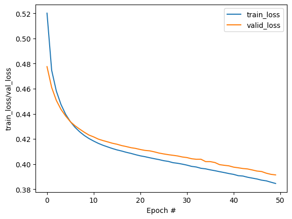

```python
# Capturing learning history per epoch
hist  = pd.DataFrame(history.history)
hist['epoch'] = history.epoch

# Plotting accuracy at different epochs
plt.plot(hist['loss'])
plt.plot(hist['val_loss'])
plt.xlabel('Epoch #')
plt.ylabel('train_loss/val_loss')
plt.legend(("train_loss" , "valid_loss") , loc =0)

#Printing results
results = model.evaluate(X_test, y_test)
```

The training loss and validation loss are very close, hence they model generalizes well. Although the accuracy is about 84%, we can attempt to improve by reducing the loss fucntion and improving the accuracy of both.

We can go ahead to check the other metrices.

```python
def make_confusion_matrix(cf,
                          group_names=None,
                          categories='auto',
                          count=True,
                          percent=True,
                          cbar=True,
                          xyticks=True,
                          xyplotlabels=True,
                          sum_stats=True,
                          figsize=None,
                          cmap='Blues',
                          title=None):
    '''
    This function will make a pretty plot of an sklearn Confusion Matrix cm using a Seaborn heatmap visualization.
    Arguments
    '''


    # CODE TO GENERATE TEXT INSIDE EACH SQUARE
    blanks = ['' for i in range(cf.size)]

    if group_names and len(group_names)==cf.size:
        group_labels = ["{}\n".format(value) for value in group_names]
    else:
        group_labels = blanks

    if count:
        group_counts = ["{0:0.0f}\n".format(value) for value in cf.flatten()]
    else:
        group_counts = blanks

    if percent:
        group_percentages = ["{0:.2%}".format(value) for value in cf.flatten()/np.sum(cf)]
    else:
        group_percentages = blanks

    box_labels = [f"{v1}{v2}{v3}".strip() for v1, v2, v3 in zip(group_labels,group_counts,group_percentages)]
    box_labels = np.asarray(box_labels).reshape(cf.shape[0],cf.shape[1])


    # CODE TO GENERATE SUMMARY STATISTICS & TEXT FOR SUMMARY STATS
    if sum_stats:
        #Accuracy is sum of diagonal divided by total observations
        accuracy  = np.trace(cf) / float(np.sum(cf))

        #if it is a binary confusion matrix, show some more stats
        if len(cf)==2:
            #Metrics for Binary Confusion Matrices
            precision = cf[1,1] / sum(cf[:,1])
            recall    = cf[1,1] / sum(cf[1,:])
            f1_score  = 2*precision*recall / (precision + recall)
            stats_text = "\n\nAccuracy={:0.3f}\nPrecision={:0.3f}\nRecall={:0.3f}\nF1 Score={:0.3f}".format(
                accuracy,precision,recall,f1_score)
        else:
            stats_text = "\n\nAccuracy={:0.3f}".format(accuracy)
    else:
        stats_text = ""


    # SET FIGURE PARAMETERS ACCORDING TO OTHER ARGUMENTS
    if figsize==None:
        #Get default figure size if not set
        figsize = plt.rcParams.get('figure.figsize')

    if xyticks==False:
        #Do not show categories if xyticks is False
        categories=False


    # MAKE THE HEATMAP VISUALIZATION
    plt.figure(figsize=figsize)
    sns.heatmap(cf,annot=box_labels,fmt="",cmap=cmap,cbar=cbar,xticklabels=categories,yticklabels=categories)

    if xyplotlabels:
        plt.ylabel('True label')
        plt.xlabel('Predicted label' + stats_text)
    else:
        plt.xlabel(stats_text)

    if title:
        plt.title(title)
```

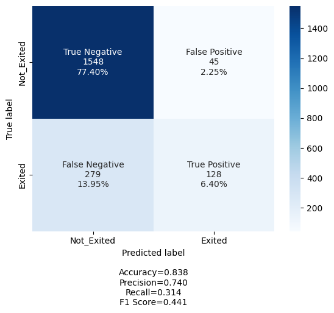

```python
## Lets determine the prediction on X_test and obtain the confusion matrix
y_pred1=model.predict(X_test)

#Let's predict using default threshold
y_pred1 = (y_pred1 > 0.5)
cm1=confusion_matrix(y_test, y_pred1)
labels = ['True Negative','False Positive','False Negative','True Positive']
categories = [ 'Not_Exited','Exited']
make_confusion_matrix(cm1,
                      group_names=labels,
                      categories=categories,
                      cmap='Blues')
```

### **Model Building 2 using Adam Optimizer**

```python
backend.clear_session()
```

```python
# Initializing the ANN
model2 = Sequential()
# The amount of nodes (dimensions) in hidden layer should be the average of input and output layers, in this case 64.
# This adds the input layer (by specifying input dimension) AND the first hidden layer (units)
model2.add(Dense(activation = 'relu', input_dim = 10, units=64))
#Add 2nd hidden layer
model2.add(Dense(32, activation='relu'))
# Adding the output layer
# we have an output of 1 node, which is the the desired dimensions of our output (stay with the bank or not)
# We use the sigmoid because we want probability outcomes
model2.add(Dense(1, activation = 'sigmoid'))
```

```python
# Create optimizer with Adam and learning rate of 0.001
# Compile the model
optimizer = tf.keras.optimizers.Adam(0.001)
model2.compile(optimizer=optimizer, loss='binary_crossentropy', metrics=['accuracy'])
```

```python
model2.summary()
```

```
Model: "sequential"
_________________________________________________________________
 Layer (type)                Output Shape              Param #
=================================================================
 dense (Dense)               (None, 64)                704

 dense_1 (Dense)             (None, 32)                2080

 dense_2 (Dense)             (None, 1)                 33

=================================================================
Total params: 2,817
Trainable params: 2,817
Non-trainable params: 0
_________________________________________________________________
```

```python
from keras import callbacks
# Defining Early stopping
es_cb = callbacks.EarlyStopping(monitor='val_loss', min_delta=0.001, patience=5)

history2=model2.fit(X_train, y_train,
          validation_split=0.2,
          epochs=50,
          batch_size=32,verbose=1)
```

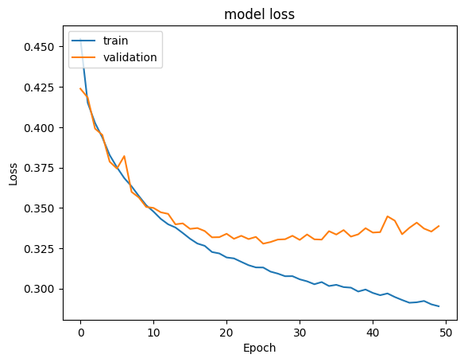

```python
#Plotting Train Loss vs Validation Loss
plt.plot(history2.history['loss'])
plt.plot(history2.history['val_loss'])
plt.title('model loss')
plt.ylabel('Loss')
plt.xlabel('Epoch')
plt.legend(['train', 'validation'], loc='upper left')
plt.show()



#Printing results
results2 = model2.evaluate(X_test, y_test)
```

- As we can see when the no of iteration increases the validation loss and training loss does not converge hence overfitting is present.
- The training data seems to have a better loss compared to validation data. There is also a bit of noise in the validation data perhaps causing slow convergence.
- We will go ahead and tune the threshold since the data is imbalanced using ROC-AUC to obtain an optimal threshold

**Let's tune the threshold using ROC-AUC**

There are many ways we could locate the threshold with the optimal balance between false positive and true positive rates.

Firstly, the true positive rate is called the Sensitivity. The inverse of the false-positive rate is called the Specificity.

Sensitivity = TruePositive / (TruePositive + FalseNegative)

Specificity = TrueNegative / (FalsePositive + TrueNegative)

Where:

Sensitivity = True Positive Rate

Specificity = 1 – False Positive Rate

The Geometric Mean or G-Mean is a metric for imbalanced classification that, if optimized, will seek a balance between the sensitivity and the specificity.

G-Mean = sqrt(Sensitivity * Specificity)

One approach would be to test the model with each threshold returned from the call roc_auc_score() and select the threshold with the largest G-Mean value.

```
Best Threshold=0.133506, G-Mean=0.782
```

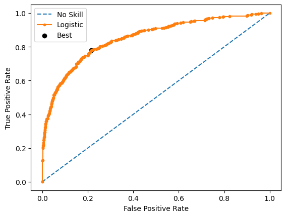

```python
from sklearn.metrics import roc_curve

from matplotlib import pyplot


# predict probabilities
yhat2 = model2.predict(X_test)
# keep probabilities for the positive outcome only
yhat2 = yhat2[:, 0]
# calculate roc curves
fpr, tpr, thresholds2 = roc_curve(y_test, yhat2)
# calculate the g-mean for each threshold
gmeans = np.sqrt(tpr * (1-fpr))
# locate the index of the largest g-mean
ix = np.argmax(gmeans)
print('Best Threshold=%f, G-Mean=%.3f' % (thresholds2[ix], gmeans[ix]))
# plot the roc curve for the model
pyplot.plot([0,1], [0,1], linestyle='--', label='No Skill')
pyplot.plot(fpr, tpr, marker='.', label='Logistic')
pyplot.scatter(fpr[ix], tpr[ix], marker='o', color='black', label='Best')
# axis labels
pyplot.xlabel('False Positive Rate')
pyplot.ylabel('True Positive Rate')
pyplot.legend()
# show the plot
pyplot.show()
```

- Here we will be using the threshold with the best G-mean value of threshold 0.13

```python
#Predicting the results using best as a threshold
y_pred2=model2.predict(X_test)
y_pred2 = (y_pred2 > thresholds2[ix])
y_pred2
```

```
array([[False],
       [False],
       [False],
       ...,
       [ True],
       [False],
       [False]])
```

```python
## Obtaining accuracy as per the classification report
from sklearn import metrics
cr=metrics.classification_report(y_test,y_pred2)
print(cr)
```

```
              precision    recall  f1-score   support

           0       0.93      0.79      0.85      1593
           1       0.48      0.78      0.59       407

    accuracy                           0.78      2000
   macro avg       0.71      0.78      0.72      2000
weighted avg       0.84      0.78      0.80      2000
```

[figure not shown]

```python
#Calculating the confusion matrix
cm2=confusion_matrix(y_test, y_pred2)
labels = ['True Positive','False Negative','False Positive','True Negative']
categories = [ 'Not Exiting','Exiting']
make_confusion_matrix(cm2,
                 group_names=labels,
                 categories=categories,
                 cmap='Blues')
```

### **Model Building 3 using regularization technique and a weight initialization**

```python
backend.clear_session()
```

```python
# Initializing the ANN
model3 = Sequential()
# The amount of nodes (dimensions) in hidden layer should be the average of input and output layers, in this case 64.
# This adds the input layer (by specifying input dimension) AND the first hidden layer (units)
model3.add(Dense(activation = 'relu', input_dim = 10, units=64))
# Add a regularization technique to reduce overfitting
model3.add(BatchNormalization())
#Add 2nd hidden layer
model3.add(Dense(32, activation='relu',kernel_initializer='he_uniform'))
model3.add(BatchNormalization())
#Add 3rd hidden layer
model3.add(Dense(16, activation='relu',kernel_initializer='he_uniform'))
# Adding the output layer
# we have an output of 1 node, which is the the desired dimensions of our output (stay with the bank or not)
# We use the sigmoid because we want probability outcomes
model3.add(Dense(1, activation = 'sigmoid'))
```

```python
# Compiling the ANN with Adam optimizer and binary cross entropy loss function
optimizer = tf.keras.optimizers.Adam(0.001)
model3.compile(loss='binary_crossentropy',optimizer=optimizer,metrics=['accuracy'])
```

```python
model3.summary()
```

```
Model: "sequential"
_________________________________________________________________
 Layer (type)                Output Shape              Param #
=================================================================
 dense (Dense)               (None, 64)                704

 batch_normalization (BatchN  (None, 64)               256
 ormalization)

 dense_1 (Dense)             (None, 32)                2080

 batch_normalization_1 (Batc  (None, 32)               128
 hNormalization)

 dense_2 (Dense)             (None, 16)                528

 dense_3 (Dense)             (None, 1)                 17

=================================================================
Total params: 3,713
Trainable params: 3,521
Non-trainable params: 192
_________________________________________________________________
```

```python
history3 = model3.fit(X_train,y_train,batch_size=64,epochs=50,verbose=1,validation_split = 0.2)
```

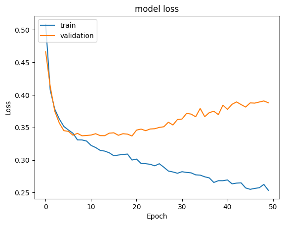

```python
#Plotting Train Loss vs Validation Loss
plt.plot(history3.history['loss'])
plt.plot(history3.history['val_loss'])
plt.title('model loss')
plt.ylabel('Loss')
plt.xlabel('Epoch')
plt.legend(['train', 'validation'], loc='upper left')
plt.show()
```

- Adding regularization did not improve the overfitting. However, the accuracy still looks good. We will try to use a better threshold to see if we can improve the model

```
Best Threshold=0.210682, G-Mean=0.765
```

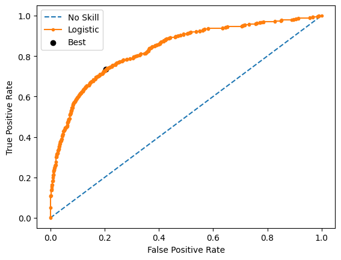

```python
from sklearn.metrics import roc_curve

from matplotlib import pyplot


# predict probabilities
yhat3 = model3.predict(X_test)
# keep probabilities for the positive outcome only
yhat3 = yhat3[:, 0]
# calculate roc curves
fpr, tpr, thresholds3 = roc_curve(y_test, yhat3)
# calculate the g-mean for each threshold
gmeans = np.sqrt(tpr * (1-fpr))
# locate the index of the largest g-mean
ix = np.argmax(gmeans)
print('Best Threshold=%f, G-Mean=%.3f' % (thresholds3[ix], gmeans[ix]))
# plot the roc curve for the model
pyplot.plot([0,1], [0,1], linestyle='--', label='No Skill')
pyplot.plot(fpr, tpr, marker='.', label='Logistic')
pyplot.scatter(fpr[ix], tpr[ix], marker='o', color='black', label='Best')
# axis labels
pyplot.xlabel('False Positive Rate')
pyplot.ylabel('True Positive Rate')
pyplot.legend()
# show the plot
pyplot.show()
```

- We will be using thereshold of 0.2

```python
#Predicting the results using best as a threshold
y_pred3=model3.predict(X_test)
y_pred3 = (y_pred3 > thresholds3[ix])
y_pred3
```

```
array([[False],
       [False],
       [False],
       ...,
       [ True],
       [False],
       [False]])
```

```python
#Accuracy as per the classification report
from sklearn import metrics
cr3=metrics.classification_report(y_test,y_pred3)
print(cr3)
```

```
              precision    recall  f1-score   support

           0       0.92      0.80      0.85      1593
           1       0.48      0.73      0.58       407

    accuracy                           0.78      2000
   macro avg       0.70      0.76      0.72      2000
weighted avg       0.83      0.78      0.80      2000
```

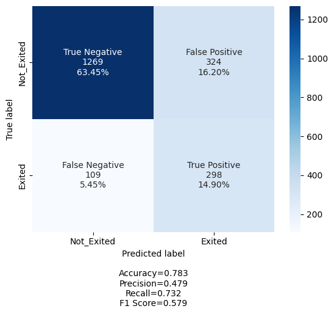

```python
cm3=confusion_matrix(y_test, y_pred3)
labels = ['True Negative','False Positive','False Negative','True Positive']
categories = [ 'Not_Exited','Exited']
make_confusion_matrix(cm3,
                      group_names=labels,
                      categories=categories,
                      cmap='Blues')
```

### **Model 4 using dropout regularization method**

```python
backend.clear_session()
np.random.seed(2)
import random
random.seed(2)
tf.random.set_seed(2)
```

```python
model4 = Sequential()
#Adding the input and first hidden layer with 8 neurons with relu as activation functions
model4.add(Dense(32,activation='relu',input_dim = X_train.shape[1]))
model4.add(Dropout(0.2))
#Adding the second hidden layer with 16 neurons with relu as activation functions
model4.add(Dense(16,activation='relu'))
model4.add(Dropout(0.1))
#Adding the third hidden layer with 8 neurons with relu as activation functions
model4.add(Dense(8,activation='relu'))
model4.add(Dense(1, activation = 'sigmoid'))
```

```python
model4.summary()
```

```
Model: "sequential"
_________________________________________________________________
 Layer (type)                Output Shape              Param #
=================================================================
 dense (Dense)               (None, 32)                352

 dropout (Dropout)           (None, 32)                0

 dense_1 (Dense)             (None, 16)                528

 dropout_1 (Dropout)         (None, 16)                0

 dense_2 (Dense)             (None, 8)                 136

 dense_3 (Dense)             (None, 1)                 9

=================================================================
Total params: 1,025
Trainable params: 1,025
Non-trainable params: 0
_________________________________________________________________
```

```python
# Compiling the ANN with Adam optimizer and binary cross entropy loss function
optimizer = tf.keras.optimizers.Adam(0.001)
model4.compile(loss='binary_crossentropy',optimizer=optimizer,metrics=['accuracy'])
```

```python
# Defining Early stopping
es_cb = callbacks.EarlyStopping(monitor='val_loss', min_delta=0.001, patience=5)

history4=model4.fit(X_train, y_train,
          validation_split=0.2,
          epochs=100,
          batch_size=32,verbose=1)
```

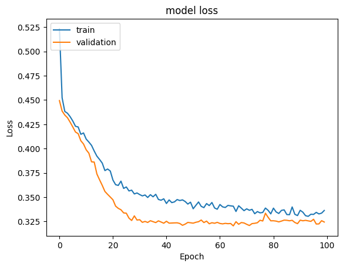

```python
#Plotting Train Loss vs Validation Loss
plt.plot(history4.history['loss'])
plt.plot(history4.history['val_loss'])
plt.title('model loss')
plt.ylabel('Loss')
plt.xlabel('Epoch')
plt.legend(['train', 'validation'], loc='upper left')
plt.show()
```

- Even though there is a bit of noise it appears the model generalizes well between the training and validation data, without overfitting.
- There is a much better convergence using 100 iterations.
- The training and validation loss seems okay and the accuracy is high in both data.
- We can attempt selecting a better threshold to see if we can reduce the loss function better than previous

```
Best Threshold=0.222548, G-Mean=0.776
```

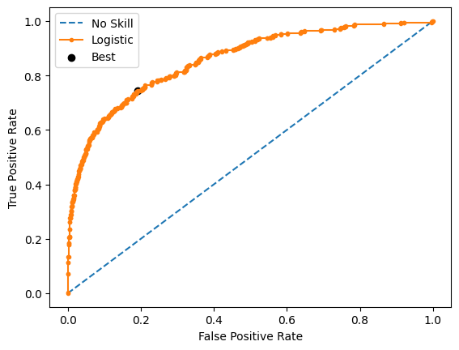

```python
from sklearn.metrics import roc_curve

from matplotlib import pyplot


# predict probabilities
yhat4 = model4.predict(X_test)
# keep probabilities for the positive outcome only
yhat4 = yhat4[:, 0]
# calculate roc curves
fpr, tpr, thresholds4 = roc_curve(y_test, yhat4)
# calculate the g-mean for each threshold
gmeans = np.sqrt(tpr * (1-fpr))
# locate the index of the largest g-mean
ix = np.argmax(gmeans)
print('Best Threshold=%f, G-Mean=%.3f' % (thresholds4[ix], gmeans[ix]))
# plot the roc curve for the model
pyplot.plot([0,1], [0,1], linestyle='--', label='No Skill')
pyplot.plot(fpr, tpr, marker='.', label='Logistic')
pyplot.scatter(fpr[ix], tpr[ix], marker='o', color='black', label='Best')
# axis labels
pyplot.xlabel('False Positive Rate')
pyplot.ylabel('True Positive Rate')
pyplot.legend()
# show the plot
pyplot.show()
```

- Lets use a threshold of 0.22 from AUC curve

```python
#Predicting the results using best as a threshold
y_pred4=model4.predict(X_test)
y_pred4 = (y_pred4 > thresholds4[ix])
y_pred4
```

```
array([[False],
       [False],
       [False],
       ...,
       [ True],
       [False],
       [False]])
```

```python
#Accuracy as per the classification report
from sklearn import metrics
cr4=metrics.classification_report(y_test,y_pred4)
print(cr4)
```

```
              precision    recall  f1-score   support

           0       0.92      0.81      0.86      1593
           1       0.50      0.74      0.60       407

    accuracy                           0.80      2000
   macro avg       0.71      0.78      0.73      2000
weighted avg       0.84      0.80      0.81      2000
```

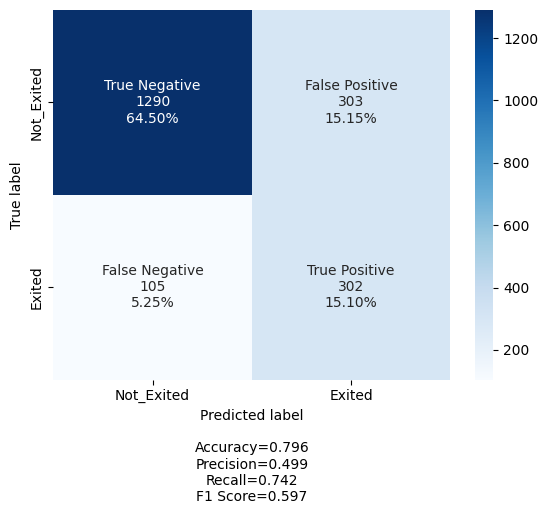

```python
cm4=confusion_matrix(y_test, y_pred4)
labels = ['True Negative','False Positive','False Negative','True Positive']
categories = [ 'Not_Exited','Exited']
make_confusion_matrix(cm4,
                      group_names=labels,
                      categories=categories,
                      cmap='Blues')
```